# **Implémentation de BLAST II (Basic local alignment search tool) en python**

## Introduction

BLAST (Altschul *et al*, 1990) est un outil incontournable de la bioinformatique, permettant de rechercher rapidement des homologues d'une séquence, nucléique ou protéique, dans des bases de données de tailles toujours grandissantes. Il est performant, puisqu'il permet d'éviter l'alignement systématique de la séquence recherchée avec l'ensemble des séquences de la base de données. Pour ce faire, la séquence est décomposée en mots de taille k, qui seront recherchés dans les séquences de la base de données. Une fois un mot retrouvé, l'alignement entre les deux séquences est étendu des deux côtés du mot. Dans le cas de BLAST II (Altschul *et al*, 1997), ce n'est pas seulement la présence d'un de ces mots qui va enclencher l'extension d'un alignement, mais celle de deux mots. Cette amélioration de l'algorithme permet de diminuer le nombre de séquences qui seront effectivement alignées, et ainsi d'implémenter un alignement local comprenant de possibles gaps, soit des insertion ou déletions par rapport à la séquence recherchée. L'algorithme d'alignement utilisé est celui de Smith et Waterman (Smith et Waterman, 1981). Le projet est donc de développer l'algorithme de BLAST II en python.

## Matériel et méthodes

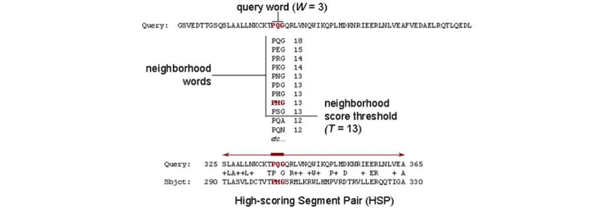

*Figure 1 : Visualisation de l'ensemble de l'algorithme BLAST*

La matrice de substitution utilisée pour calculer l'ensemble des scores d'alignement lors de ce projet est la matrice BLOSUM62 (Henikoff et Henikoff, 1992) mais d'autres matrices peuvent être selectionnées. On **recherche ensuite ces mots dans une base de données de séquences**. On appelle un mot aligné de cette manière un "hit" (figure 2A). Dans le cas de BLAST II, deux hits se situant sur la même diagonale et au sein d'une distance de 40 résidus l'un de l'autre seront nécessaires pour lancer l'étape d'**alignement des séquences** (figure 2B et C). Cette étape consiste à joindre tout d'abord les deux hit trouvés, puis étendre l'alignement en partant des deux extrémités.

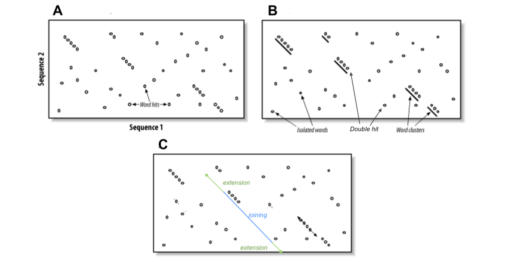

*Figure 2 : A) Visualisation des hits obtenus sur la sequence 2 à partir de la séquence 1. B) Hits isolés, clusters de hits et double hits (sur une même diagonale) C) Jointure et extension des alignments à partir des double hits*

C'est l'algorithme de Smith et Waterman qui est utilisé pour étendre l'alignement (figure 3), permettant ainsi de prendre en compte des insertions ou déletions entre les deux séquences. L'alignement est ainsi étendu jusqu'à ce que le score le caractérisant atteigne une valeur maximale. Les alignements ainsi obtenus sont ordonnés par score décroissant, et les 100 meilleurs alignements sont affichés.

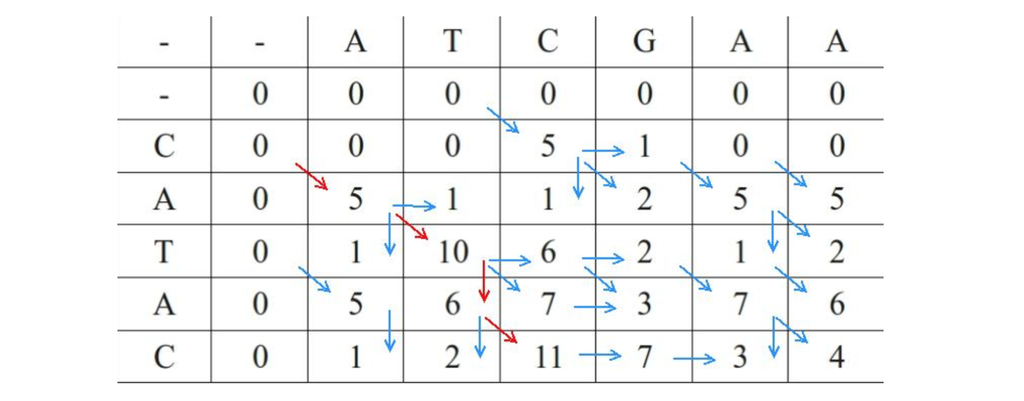

*Figure 3 : Matrice de score de l'algorithme de Smith et Waterman. Dans ce cas, l'alignement choisi pour l'extension est celui indiqué par les flèches rouges, dont le score maximal atteint est de 11*

Certains paramètres utilisés pour cette implémentation peuvent être réglés en début de script. C'est le cas de la taille des mots, de la matrice de score, du treshold pour le score du mot, de la distance maximale entre les deux hits d'un double hit, et enfin des pénalitées d'ouverture et d'élongation de gap.

Pour l'implémentation de cet algorithme, les modules pythons utilisés sont le module 'math' pour les fonctions de calcul, 'numpy' pour la gestion des matrices de score avec les numpy.arrays, 'biopython' pour la gestion des sequences sous forme d'objets Seq, pour l'importation des fichiers fasta, et pour l'utilisation des matrices intégrées au module.

## Comparaison des résultats avec l'outil BLAST

Afin de déterminer la justesse de l'algorithme développé, une séquence protéique (Photosystème II D2 de *Chlamydomonas reinhardtii*, numéro d'accession PDB : P06007) a été recherchée dans une partie de la base de données RefSeq, comprenant l'ensemble des séquences protéiques de photosystèmes II de virus et d'Archées (~2000 séquences). Cette recherche a été d'une part effectuée en utilisant l'algorithme développé, d'autre part en utilisant l'algorithme d'alignement de BLASTP dans la sous base de données mentionnée. Les premiers alignements obtenus dans chaque cas peuvent être retrouvés dans les tableaux 1 et 2. On remarque que dans les deux cas la première séquence est YP_009324375.1. Si les ordres dans le classement par rapport au score ne sont pas équivalent, Les séquences retrouvées dans le top 6 sont identiques. Dans l'ensemble des cas, les scores présentent un différence de 90 bits entre l'alignement de BLASTP et l'alignement de l'algorithme développé. Cela s'explique en partie par l'utilisation de paramètres lambda et K choisis de manière arbitraire (respectivement 0.3 et 0.13) pour la normalisation du score. Ces paramètres dépendent du nombre de séquences et d'acides aminés dans la base de données, et leur calcul n'a pour le moment pas été implémenté.

**Tableau 1 : Six meilleurs alignements avec BLASTP**

|  | ID | eval | score |
| --- | --- | --- | --- |
| 0 | YP_009324375.1 | 0.0 | 620 |
| 1 | YP_010669555.1 | 0.0 | 618 |
| 2 | YP_009322642.1 | 0.0 | 616 |
| 3 | YP_003097254.1 | 0.0 | 616 |
| 4 | YP_009133529.1 | 0.0 | 615 |
| 5 | YP_010355357.1 | 0.0 | 615 |

**Tableau 2 : Six meilleurs alignements avec la version de BLAST développée**

|  | ID | score | evalue |
| --- | --- | --- | --- |
| 0 | YP_009324375.1 | 709.72 | 7.936323e-212 |
| 1 | YP_003097254.1 | 707.56 | 3.536604e-211 |
| 2 | YP_010669555.1 | 706.69 | 6.480936e-211 |
| 3 | YP_009322642.1 | 705.39 | 1.539710e-210 |
| 4 | YP_010355357.1 | 702.79 | 9.369497e-210 |
| 5 | YP_009133529.1 | 702.79 | 9.369497e-210 |

L'arrondi appliqué aux E-values de BLASTP ne permet pas la comparaison de ces valeurs puisqu'elles sont quasi égales à 0 dans les deux cas. On a donc bien des séquences avec une homologie certaine. Un test de corrélation de Spearmann (rho = 0.0307, pvalue=0.762) montre qu'on a peu de corrélation entre les rangs des 100 alignements donnés par les deux algorithmes. On a donc une assez mauvaise corrélation des rangs.

## Réferences

Altschul, S. F., Gish, W., Miller, W., Myers, E. W., & Lipman, D. J. (1990). Basic local alignment search tool. *Journal of Molecular Biology, 215*(3), 403–410. https://doi.org/10.1016/S0022-2836(05)80360-2

Altschul, S. F., Madden, T. L., Schäffer, A. A., Zhang, J., Zhang, Z., Miller, W., & Lipman, D. J. (1997). Gapped BLAST and PSI-BLAST: A new generation of protein database search programs. *Nucleic Acids Research, 25*(17), 3389–3402. https://doi.org/10.1093/nar/25.17.3389

Henikoff, S., & Henikoff, J. G. (1992). Amino acid substitution matrices from protein blocks. *Proceedings of the National Academy of Sciences of the United States of America, 89*(22), 10915–10919. https://doi.org/10.1073/pnas.89.22.10915

Smith, T. F., & Waterman, M. S. (1981). Identification of common molecular subsequences. *Journal of Molecular Biology, 147*(1), 195–197. https://doi.org/10.1016/0022-2836(81)90087-5